# Simple Normal Regression Analysis

audreybertin

2020-12-08 15:15:27

## Analysis Inputs

#### Data:

```
## 'data.frame':    333 obs. of  8 variables:
##  $ species          : chr  "Adelie" "Adelie" "Adelie" "Adelie" ...
##  $ island           : chr  "Torgersen" "Torgersen" "Torgersen" "Torgersen" ...
##  $ bill_length_mm   : num  39.1 39.5 40.3 36.7 39.3 38.9 39.2 41.1 38.6 34.6 ...
##  $ bill_depth_mm    : num  18.7 17.4 18 19.3 20.6 17.8 19.6 17.6 21.2 21.1 ...
##  $ flipper_length_mm: int  181 186 195 193 190 181 195 182 191 198 ...
##  $ body_mass_g      : int  3750 3800 3250 3450 3650 3625 4675 3200 3800 4400 ...
##  $ sex              : chr  "male" "female" "female" "female" ...
##  $ year             : int  2007 2007 2007 2007 2007 2007 2007 2007 2007 2007 ...
##  - attr(*, "na.action")= 'omit' Named int [1:9] 8 9 10 11 177 217 255 267 270
##   ..- attr(*, "names")= chr [1:9] "8" "9" "10" "11" ...
```

#### Credible Interval Percentage: 95

#### Number Of Potential Regression Lines To Graph: 83

#### Values For X With Which To Predict Posterior Distributions Of Y: 190, 200, 210

#### Number Of Folds To Use With Cross-Validation: 10

## Plot of flipper_length_mm (X) & body_mass_g (Y)

Below, we see a scatterplot of our X & Y variables of interest, flipper_length_mm and body_mass_g:

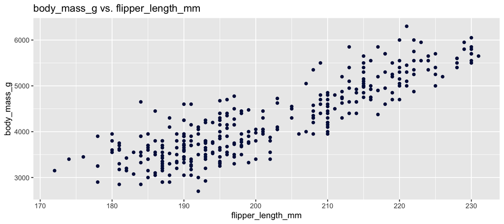

## Visual Diagnostics

To evaluate the quality of the model, we consider several visual diagnostics: trace plots and chain density overlay plots.

#### Trace Plots

Trace plots show us the patterns of our chain values across all of their iterations. Based on the appearance of those plots, we can determine whether the model was an effective simulation or not.

What you **want** to see:

- A bunch of white noise

What you **DO NOT want** to see:

- A clear non-zero slope in the movement of the chains across all iterations. For example, as iterations increase, you can see that the chain values consistently increase/decrease.
- Sections where the chain appears to get stuck. These will be visible as breaks in the plot where there is only a horizontal line rather than vertical white noise.

> If you see any of the above problems, please increase the number of iterations (`n_iter`) until you are satisfied with the model's quality before proceeding.

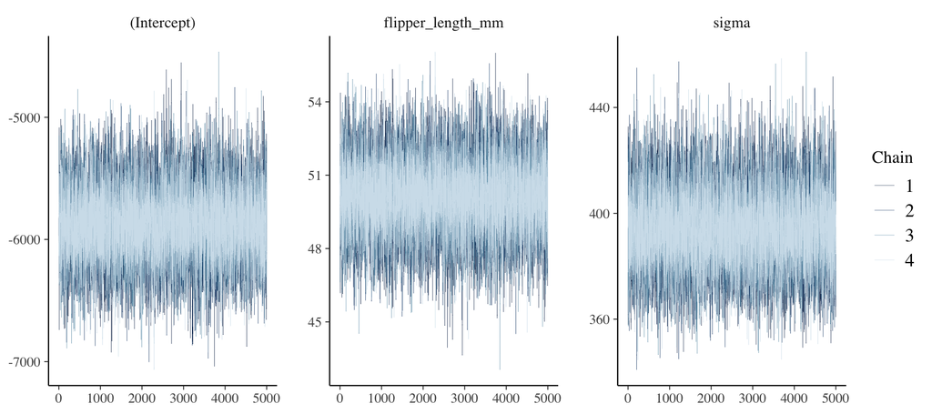

#### Chain Density Overlay Plots

Chain density overlay plots also help determine whether the simulation was accurate. These show overlaid density plots of the posterior distributions found all of our parameters in each chain.

What you **want** to see:

- For each parameter (intercept, slope, sigma), the density plots should look almost identical.
- It is okay if there are slight deviations in density as long as the peaks of the density plots are very similar, as are their ranges and shapes.

What you **DO NOT want** to see:

- Chains with different distributions (different peaks, ranges, and/or shapes)

> If you see any of the above problems, please increase the number of iterations (`n_iter`) until you are satisfied with the model's quality before proceeding.

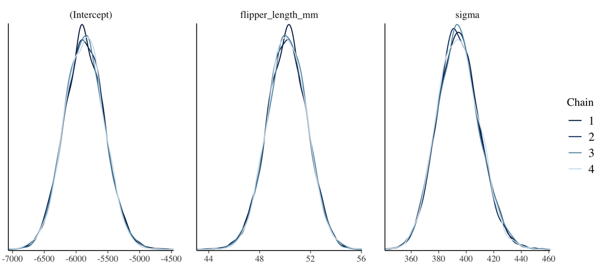

## Posterior Summary Statistics and Mathematical Diagnostics

Below are the summary statistics for the posterior of our simple normal regression model:

|  | mean | mcse | sd | 10% | 50% | 90% | n_eff | Rhat |
| --- | --- | --- | --- | --- | --- | --- | --- | --- |
| (Intercept) | -5871.70788 | 2.2104187 | 314.722517 | -6273.27883 | -5872.98941 | -5469.80582 | 20272 | 1.0000106 |
| flipper_length_mm | 50.15094 | 0.0109819 | 1.563594 | 48.15207 | 50.15574 | 52.14568 | 20272 | 1.0000131 |
| sigma | 394.35775 | 0.1079921 | 15.345225 | 374.95338 | 393.91286 | 414.43110 | 20191 | 0.9998925 |

The main columns to pay attention to are:

1. mean
2. n_eff
3. Rhat

Using these three columns, we can determine the *average* regression equation across all of our iterations (using 'mean') as well as get a sense of whether or not the chains produced an accurate estimate of the posterior (using 'n_eff' and 'Rhat').

#### Best Guess For Regression Equation ('mean'):

$$\hat{\text{body_mass_g}} = -5871.71 + 50.15 * \text{flipper_length_mm}$$

#### Number of Effective Iterations / Effective Sample Size ('n_eff'):

N_eff quantifies the number of independent samples it would take to produce an equivalently accurate posterior approximation as created by the Stan model.

We should be **suspicious** of the quality of our model if N_eff is less than 10% of the number of iterations run by our model across all of its chains.

**In the table below, parameters for which suspicious values of n_eff were found are highlighted red. If NO rows are red, then your model is likely okay in terms of its number of effective iterations!**

[output not shown]

#### Variability Across vs Within Chains ('Rhat'):

Rhat measures the ratio between:

1. The combined variability in our parameter across all chains, and
2. The typical variability within any individual chain.

Rhat values $\approx$ 1 indicate **stability** across chains, while Rhat values > 1 indicate **instability**.

**In the table below, parameters for which suspicious values of Rhat were found are highlighted red. If NO rows are red, then your model is likely okay in terms its chain variability ratio!**

|  | Rhat | Unstable? |
| --- | --- | --- |
| (Intercept) | 1.0000106 | No |
| flipper_length_mm | 1.0000131 | No |
| sigma | 0.9998925 | No |

## Credible Intervals

Below we see 95% Credible Intervals for the posterior distribution of our three parameters: the intercept, slope, and the standard deviation of our data around the proposed regression line.

|  | 2.5% | 97.5% |
| --- | --- | --- |
| (Intercept) | -6484.13254 | -5250.57789 |
| flipper_length_mm | 47.06641 | 53.19209 |
| sigma | 365.64468 | 425.42840 |

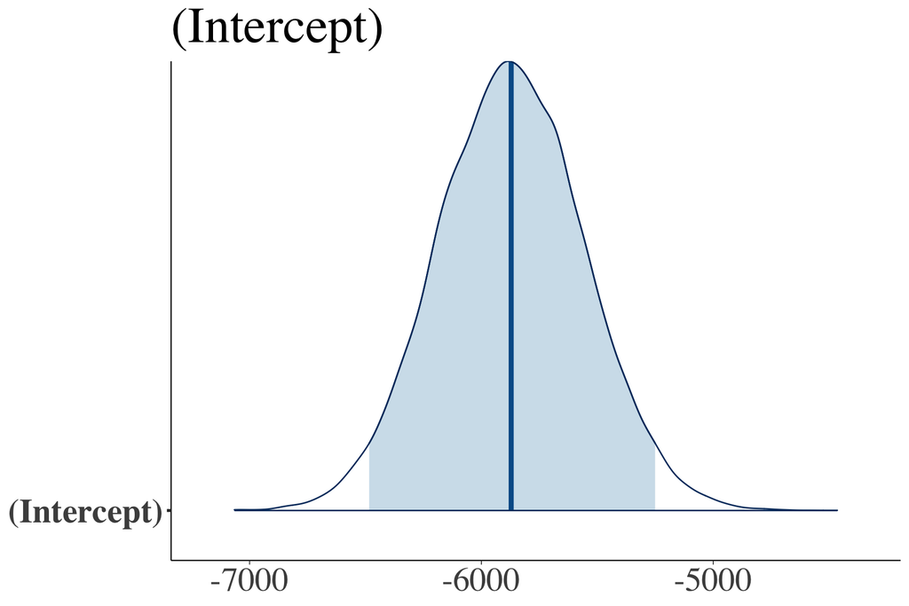

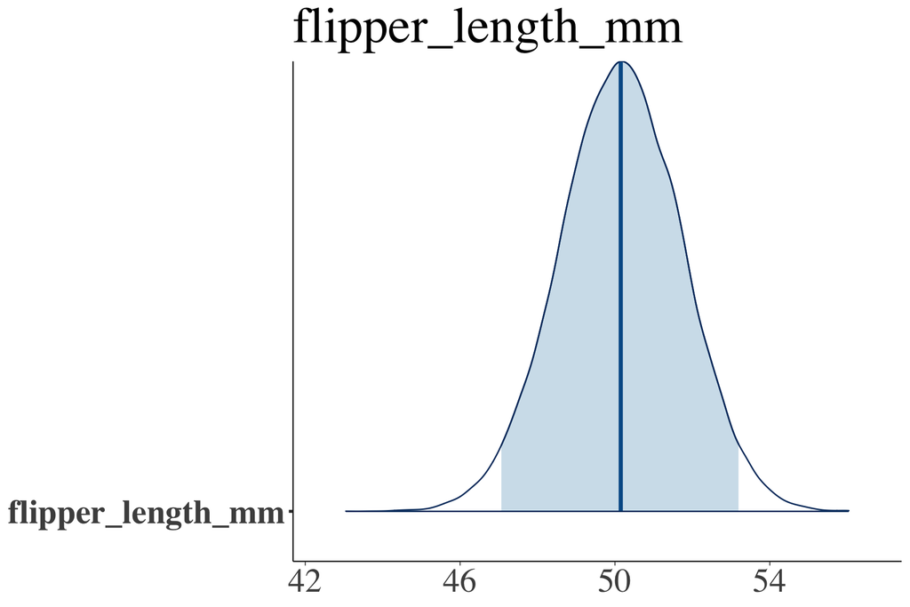

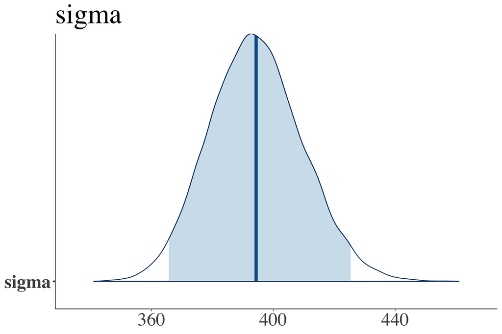

There is a 95% posterior probability that the:

- **intercept** of the model is between -6484.13 and -5250.58.
- **slope** (flipper_length_mm) of the model is between 47.07 and 53.19.
- **sigma** (standard deviation) of the model is between 365.64 and 425.43.

## Plot of Potential Regression Lines Determined By Model

Below is a plot of 83 potential regression lines proposed by the model (plotted in medium blue) alongside the mean proposed regression line (plotted in dark blue):

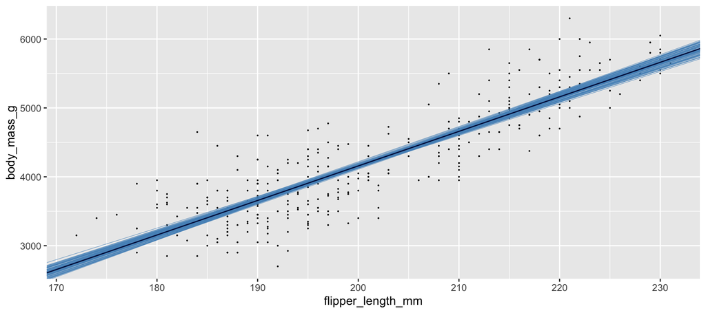

## Posterior Probability of Calculated Slope

The slope found by the model was **positive**. The estimated posterior probability that the true slope is in the same direction as the one you found ( > 0) is 1.

| fits_condition | n | percent |
| --- | --- | --- |
| TRUE | 20000 | 1 |

## Posterior Predictions

Below are the predicted posterior distributions of body_mass_g when flipper_length_mm = the following value(s): 190, 200, 210

$~$

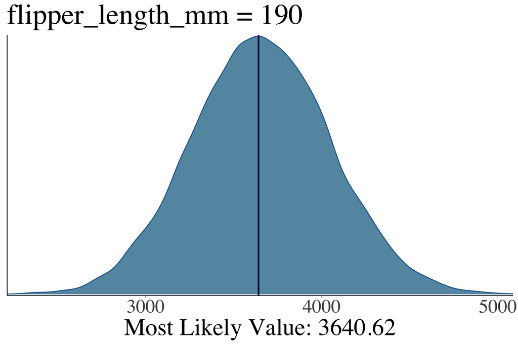

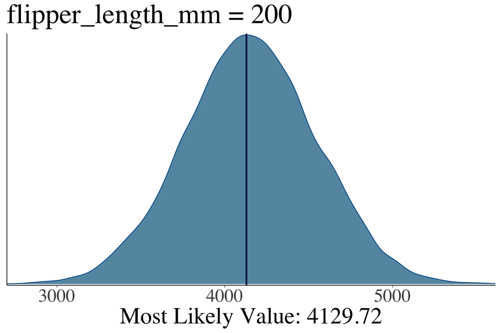

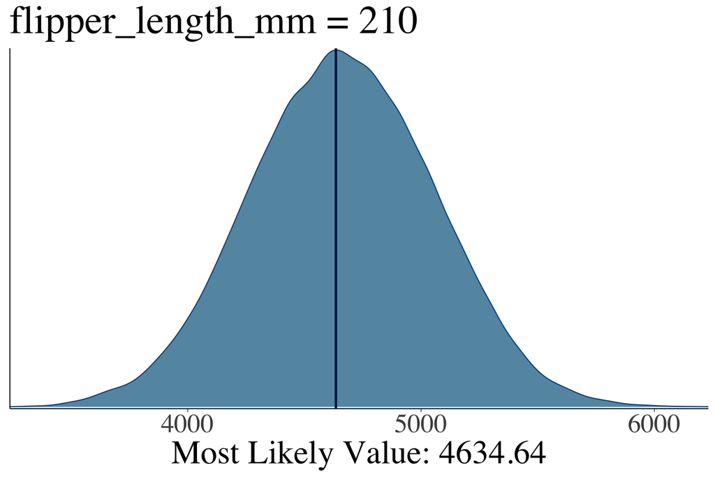

## Evaluating Prediction Quality

#### Posterior Predictive Check

The posterior predictive check compares the distribution of our data (dark blue) with the distribution of our predictions (light blue).

We have a high quality model if the following features our distributions are similar:

- Range
- Mode
- Shape

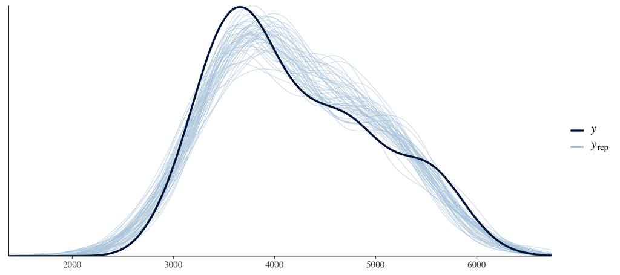

#### Posterior Prediction Intervals

The graph below provides a quick visual summary of how consistent the observed outcomes/data (dark blue dots) are with the range of predictions made by posterior model (light blue lines).

The model is of high quality if:

- The vast majority of dark blue dots fall within the light blue bars, AND
- Within the light blue region, the dots cluster more toward the middle than toward the outside.

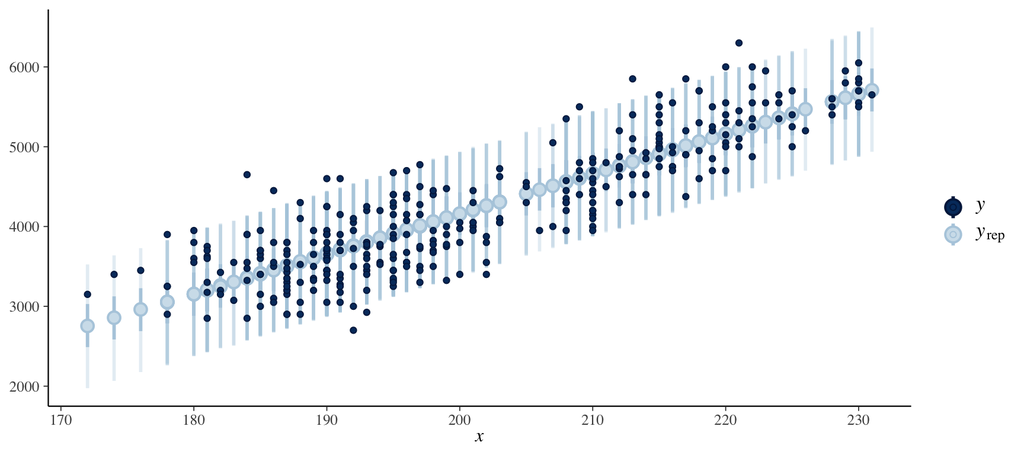

#### Cross Validation

Finally, we can use cross-validation to get a sense of how well our model will work when given entirely new data!

Below, we see summaries of model quality for a cross-validation model with 10 folds:

| mae | mae_scaled | within_50 | within_95 |
| --- | --- | --- | --- |
| 266.0622 | 0.9985501 | 0.5111408 | 0.9459893 |

- The `mae` (median absolute error) value means that the typical difference between the observed data points and their posterior predictive medians is 266.0621677.
- The `mae_scaled` (scaled median absolute error) value means that the typical number of absolute deviations between the observed data points and their posterior predictive medians is 0.9985501
- The `within_50` and `within_95` statistics measure the proportion of observed values that fall within the 50% and 95% posterior prediction intervals, respectivelyl. For this model, those values are 0.5111408 (50%) and 0.9459893 (95%).

High quality models have the following characteristics:

- `mae` values are dependent on the scale of the data. They should be as small as possible.
- `mae_scaled` should be relatively close to 1 (and definitely less than 2).
- `within_50` should be around 0.5 (higher values are better).
- `within_95` should be around 0.95 (higher values are better).